# Regresion

```r
library(GGally)
library(caTools)
library(lessR)
library(Metrics)
```

# Tarea 3

#### Estudiante:

- Brian Durán

## Regresión lineal

Análisis del Problema

El desempeño de un automóvil se puede medir de diferentes formas. Algunas comunes son la cantidad de caballos de fuerza y el rendimiento del mismo, que se puede resumir en cuantas millas puede recorrer el automóvil por cada galón de combustible que consume. Para los clientes, potenciales compradores de un automóvil, este rendimiento es importante pues puede ayudar a tomar una decisión con respecto a cuál automóvil comprar (si, por ejemplo, el cliente quiere un auto que rinda por muchas millas y pueda economizar en la compra de combustible).

Desde este punto de vista, tanto a clientes como a fabricadores de automóviles, les conviene entender cuál es la relación entre diferentes características del automóvil y su rendimiento, pues el conocer estas relaciones les puede ayudar a inferir cuál va a ser la eficiencia del vehículo a partir de ver los valores de otras características. Para fabricantes, puede ser importante conocer estas relaciones para saber cómo hacer cada modelo más eficiente con respecto al anterior.

Entendimiento de los Datos

Con el fin de analizar y tratar de estimar las millas por galón de diferentes modelos de automóviles, se trabajó con un conjunto de datos que contiene 398 observaciones y 9 variables:

- mpg (millas por galón): numérica, con un rango de 9 a 46.60.
- cyl (cilindraje): categórica ordinal, con valores posibles de 3, 4, 5, 6 y 8.
- disp (desplazamiento): numérica, con un rango de 68 a 455.
- hp (caballos de fuerza): numérica, con un rango de 46 a 230 y 6 valores faltantes.
- weight (peso): numérica, con un rango de 1613 a 5140.
- acc (aceleración): numérica, con un rango de 8 a 24.80.
- model year (año): categórica, con 13 valores diferentes representando el año del automóvil.
- origin (origen): categórica, 3 valores posibles: 1, 2, 3.
- model name (nombre del modelo): categórica, con 305 posibles valores.

# Ejercicios

1. Cargue el archivo auto-mpg_g.csv en una variable

```r
datos_autos <- read.csv("auto-mpg_g.csv")
head(mpg)
```

| manufacturer | model | displ | year | cyl | trans | drv | cty | hwy | fl | class |
| --- | --- | --- | --- | --- | --- | --- | --- | --- | --- | --- |
| audi | a4 | 1.8 | 1999 | 4 | auto(l5) | f | 18 | 29 | p | compact |
| audi | a4 | 1.8 | 1999 | 4 | manual(m5) | f | 21 | 29 | p | compact |
| audi | a4 | 2.0 | 2008 | 4 | manual(m6) | f | 20 | 31 | p | compact |
| audi | a4 | 2.0 | 2008 | 4 | auto(av) | f | 21 | 30 | p | compact |
| audi | a4 | 2.8 | 1999 | 6 | auto(l5) | f | 16 | 26 | p | compact |
| audi | a4 | 2.8 | 1999 | 6 | manual(m5) | f | 18 | 26 | p | compact |

2. Utilizando Ggpairs cree un gráfico de los atributos del dataset, observe las correlaciones entre atributos

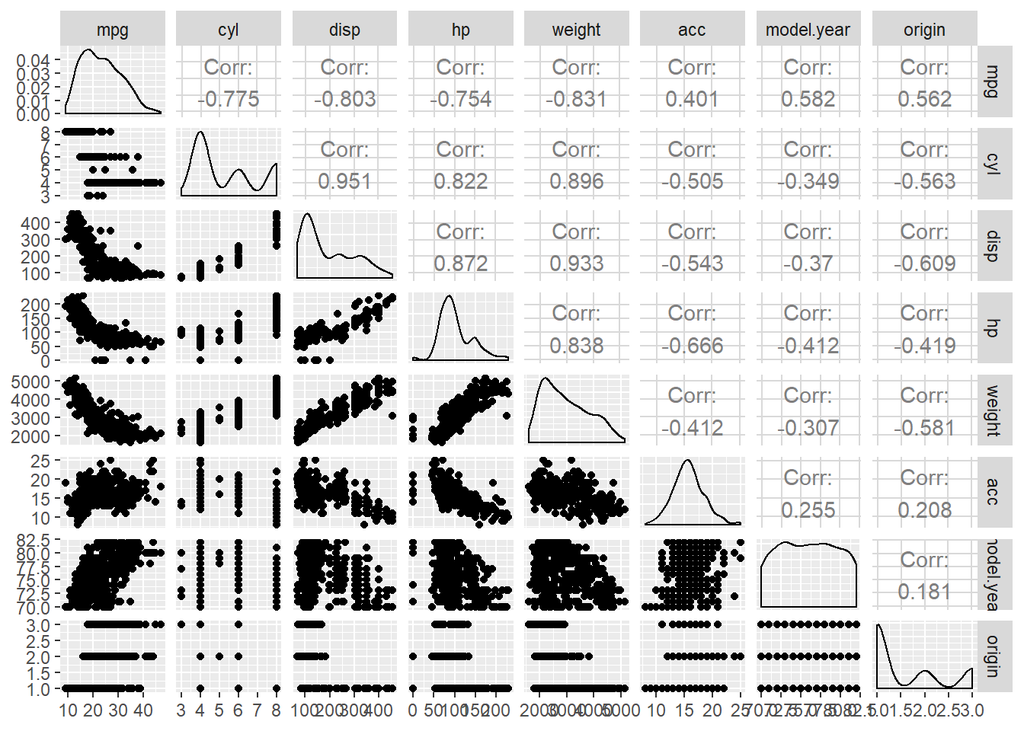

```r
ggpairs(datos_autos, columns = 1:8)
```

3. Separe los datos en 2 conjuntos, uno de entrenamiento y otro de pruebas. Normalmente se trabaja utilizando un 70-80% de los datos para entrenamiento y el resto para pruebas.

Recuerde fijar una semilla para que el documento sea reproducible.

Pista: https://www.rdocumentation.org/packages/caTools/versions/1.17.1/topics/sample.split

```r
set.seed(1)
msk <- sample.split(datos_autos[,1], SplitRatio = 4/5, group = NULL)
train <- datos_autos[ msk,]
test  <- datos_autos[!msk,]
```

4. Cree un modelo de regresion lineal utilizando el atributo mpg como la variable objetivo y en base a las correlaciones observadas en el gráfico del punto 2 escoja al menos dos atributos para usarlos como variables predictoras para el modelo.

Pista: https://www.rdocumentation.org/packages/lessR/versions/1.9.8/topics/reg

Nota: Al crear el modelo utilice el conjunto de datos de entrenamiento definido en el punto 3.

```r
regresion <- lm(mpg ~ disp + weight, data=train)
regresion
```

```
##
## Call:
## lm(formula = mpg ~ disp + weight, data = train)
##
## Coefficients:
## (Intercept)         disp       weight
##   44.539572    -0.013319    -0.006154
```

5. Realice predicciones utilizando el conjunto de pruebas y evalue el resultado con la métrica MSE.

Pista: https://www.rdocumentation.org/packages/mltools/versions/0.3.5/topics/mse

```r
prediccion <- predict(regresion, test)
error <- Metrics::mse(test$mpg, prediccion)
error
```

```
## [1] 15.38798
```

### Análisis

Se realizó una regresión lineal para el atributo mpg con 2 variables predictoras, desplazamiento y peso (*disp y weight*); las cuales poseían las correlaciones más relevantes con relación a la variable principal (**mayores correlaciones negativas**). Este modelo, tal y como se solicitó, se creó utilizando el set de datos de entrenamiento (equivalente a un 80% de los datos) y luego se realizaron las predicciones correspondientes con el conjunto de datos destinados para pruebas. Al calcular el **mse** se obtiene un valor alto, pero también hay que considerar los datos no han sdo normalizados aún.

6. Opcional

6.a Pruebe varios modelos que utilicen diferentes variables y comparar los resultados obtenidos

```r
mala_regresion <- lm(mpg ~ acc + origin, data=train)
mala_prediccion <- predict(mala_regresion, test)
mayor_error <- Metrics::mse(test$mpg, mala_prediccion)
mayor_error
```

```
## [1] 28.01086
```

Al crear un modelo con los attributos *aceleración* y *origen* como variables predictores, se obtiene que el **mse** es aún mayor, lo cual era lo esperado ya que las correlaciones de dichas variables con **mpg** no son relevantes (son las más cercanas a cero)

6.b Investigar como implementar en R las técnicas de preprocesado y normalización vistas en clase y aplicarlas a los datos antes de pasarlos al modelo.

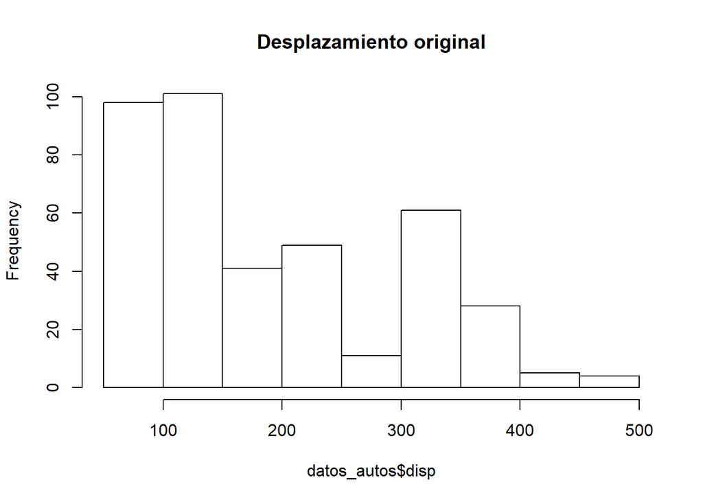

```r
datos_autos_normalizados <- read.csv("auto-mpg_g.csv")

datos_autos_normalizados$disp <- log(datos_autos_normalizados$disp)
datos_autos_normalizados$weight <- log(datos_autos_normalizados$weight)

hist(datos_autos$disp, main="Desplazamiento original")
```

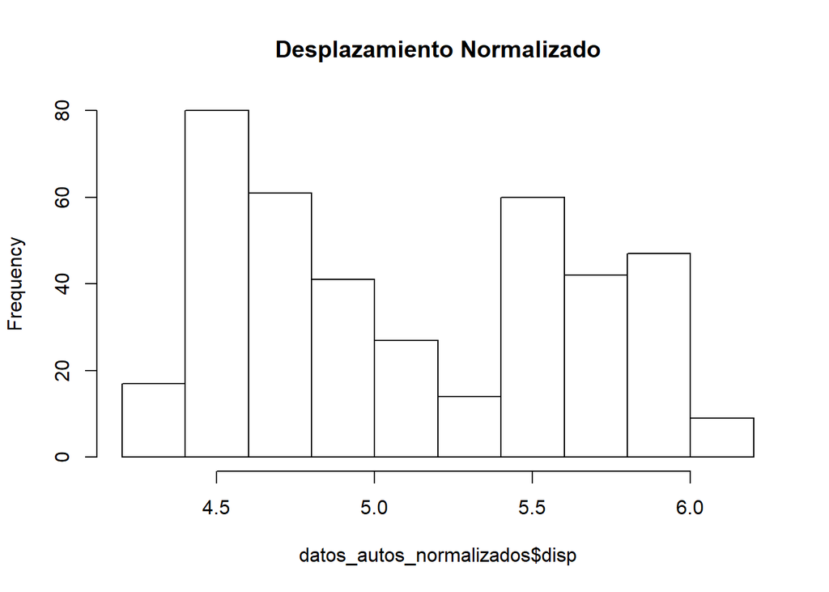

```r
hist(datos_autos_normalizados$disp, main="Desplazamiento Normalizado")
```

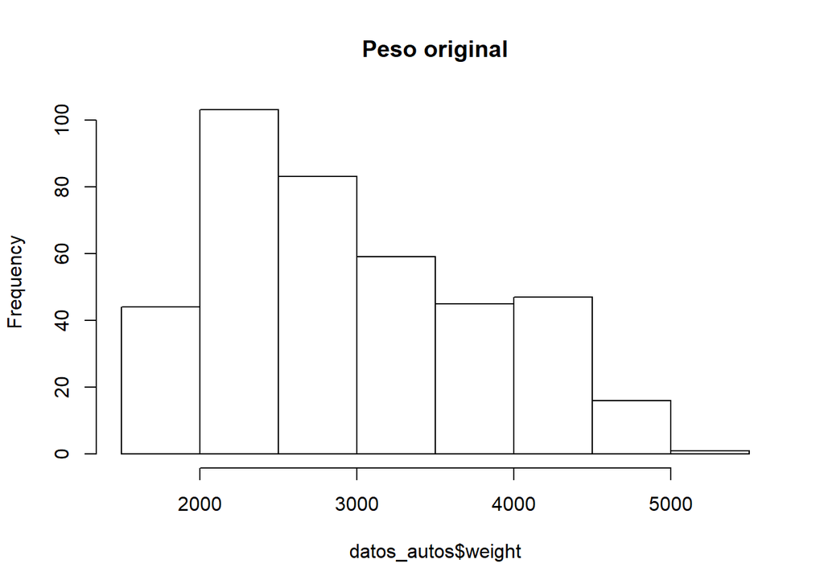

```r
hist(datos_autos$weight, main="Peso original")
```

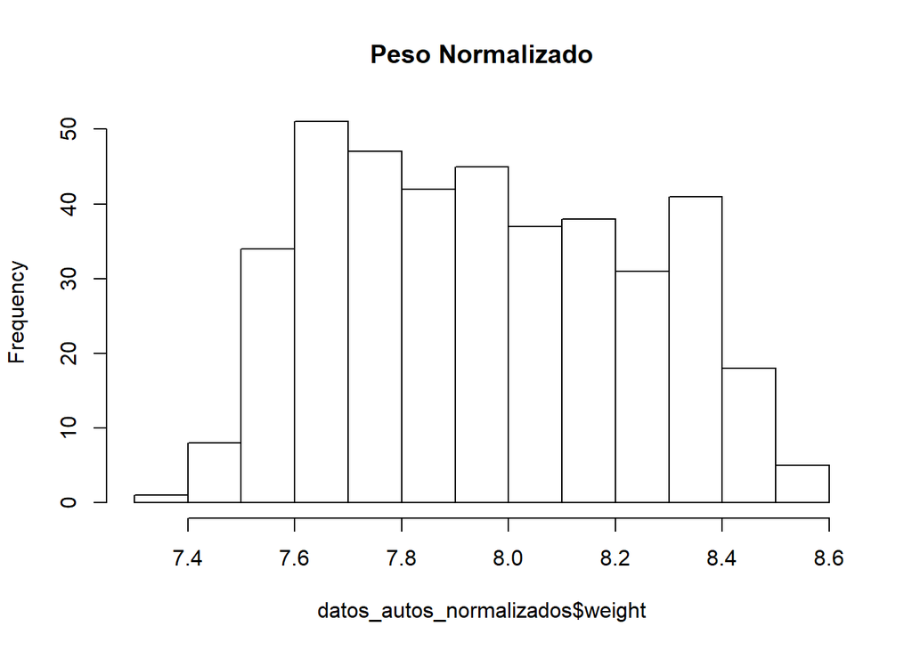

```r
hist(datos_autos_normalizados$weight, main="Peso Normalizado")
```

Podemos ver que ahora el desplazamiento y el peso se acercan más a una distribución normal.

Ahora generamos un set de datos de entrenamiento y pruebas:

```r
set.seed(1)
relacion_dividida <- sample.split(datos_autos_normalizados[,1], SplitRatio = 4/5, group = NULL)
entrenamiento <- datos_autos_normalizados[ relacion_dividida,]
pruebas  <- datos_autos_normalizados[!relacion_dividida,]
```

Ahora creamos un nuevo modelo con el grupo de datos de entrenamiento:

```r
regresion_mejorada <- lm(mpg ~ disp + weight, data=entrenamiento)
regresion_mejorada
```

```
##
## Call:
## lm(formula = mpg ~ disp + weight, data = entrenamiento)
##
## Coefficients:
## (Intercept)         disp       weight
##     175.891       -3.822      -16.671
```

Y generamos una predicción con los datos de prueba y obtenemos el error cuadrático medio (**mse**):

```r
prediccion_mejorada <- predict(regresion_mejorada, pruebas)
menor_error <- Metrics::mse(pruebas$mpg, prediccion_mejorada)
menor_error
```

```
## [1] 13.38531
```

Se puede apreciar que después de aplicar un logaritmo a las variables predictoras, el **mse** del modelo es menor.